# **Data Science con `R`**

En el resumen, primero vemos la distribución asumida, así como la función de enlace utilizada, en este caso normal e identidad. Después vemos que la salida se separa en partes paramétricas y suaves, o no paramétricas.

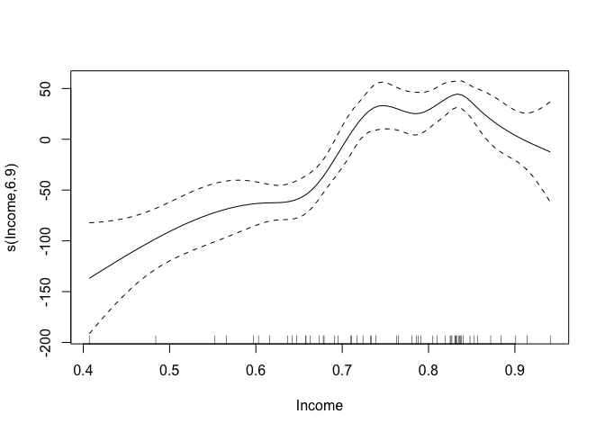

```r
plot(mod_gam1)
```

GAM multiple

```r
mod_lm2 <- gam(Overall ~ Income + Edu + Health, data=pisa)
summary(mod_lm2)
```

```
##
## Family: gaussian
## Link function: identity
##
## Formula:
## Overall ~ Income + Edu + Health
##
## Parametric coefficients:
##             Estimate Std. Error t value Pr(>|t|)
## (Intercept)   121.18      78.97   1.535   0.1314
## Income        182.32      85.27   2.138   0.0376 *
## Edu           234.11      54.78   4.274 9.06e-05 ***
## Health         27.01     134.90   0.200   0.8421
## ---
## Signif. codes:  0 '***' 0.001 '**' 0.01 '*' 0.05 '.' 0.1 ' ' 1
##
##
## R-sq.(adj) =  0.616   Deviance explained = 63.9%
## GCV = 1212.3  Scale est. = 1119      n = 52
```

```r
mod_gam2 <- gam(Overall ~ s(Income) + s(Edu) + s(Health), data=pisa)
summary(mod_gam2)
```

```
##
## Family: gaussian
## Link function: identity
##
## Formula:
## Overall ~ s(Income) + s(Edu) + s(Health)
##
## Parametric coefficients:
##             Estimate Std. Error t value Pr(>|t|)
## (Intercept)  471.154      2.772     170   <2e-16 ***
## ---
## Signif. codes:  0 '***' 0.001 '**' 0.01 '*' 0.05 '.' 0.1 ' ' 1
##
## Approximate significance of smooth terms:
##             edf Ref.df     F  p-value
## s(Income) 7.593  8.415 8.826 1.33e-07 ***
## s(Edu)    6.204  7.178 3.308  0.00733 **
## s(Health) 1.000  1.000 2.736  0.10661
## ---
## Signif. codes:  0 '***' 0.001 '**' 0.01 '*' 0.05 '.' 0.1 ' ' 1
##
## R-sq.(adj) =  0.863   Deviance explained = 90.3%
## GCV = 573.83  Scale est. = 399.5     n = 52
```

Hay de nuevo un par de cosas de las que hay que tomar nota. En primer lugar, estadísticamente hablando, llegamos a la misma conclusión que el modelo lineal con respecto a los efectos individuales. Hay que tener especialmente en cuenta el efecto del índice de salud. Los grados efectivos de libertad con el valor 1 sugieren que se ha reducido esencialmente a un simple efecto lineal. A continuación se actualizará el modelo para modelar explícitamente el efecto como tal, los resultados son idénticos.

```r
mod_gam2B = update(mod_gam2, .~.-s(Health) + Health)
summary(mod_gam2B)
```

```
##
## Family: gaussian
## Link function: identity
##
## Formula:
## Overall ~ s(Income) + s(Edu) + Health
##
## Parametric coefficients:
##             Estimate Std. Error t value Pr(>|t|)
## (Intercept)    640.3      102.3   6.260 3.06e-07 ***
## Health        -189.5      114.6  -1.654    0.107
## ---
## Signif. codes:  0 '***' 0.001 '**' 0.01 '*' 0.05 '.' 0.1 ' ' 1
##
## Approximate significance of smooth terms:
##             edf Ref.df     F  p-value
## s(Income) 7.593  8.415 8.826 1.33e-07 ***
## s(Edu)    6.204  7.178 3.308  0.00733 **
## ---
## Signif. codes:  0 '***' 0.001 '**' 0.01 '*' 0.05 '.' 0.1 ' ' 1
##
## R-sq.(adj) =  0.863   Deviance explained = 90.3%
## GCV = 573.83  Scale est. = 399.5     n = 52
```

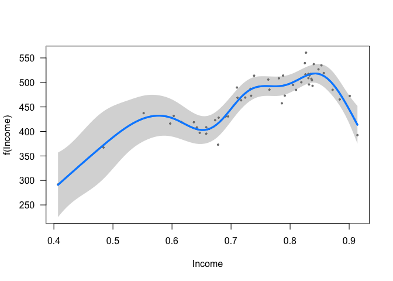

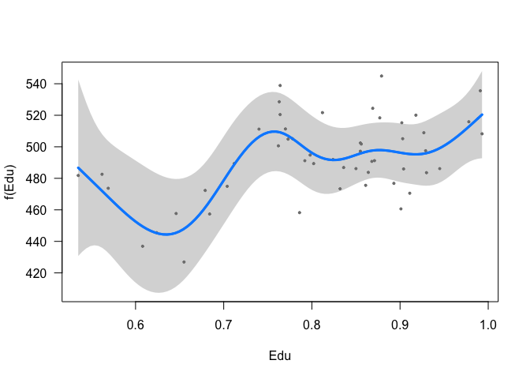

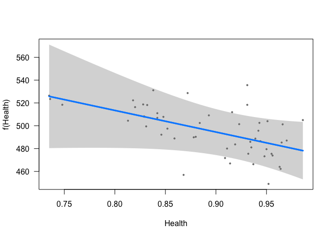

```r
visreg(mod_gam2)
```

El GAM nos da un sentido para un predictor, pero ahora vamos a echar un vistazo a los ingresos y la educación al mismo tiempo.`vis.gam`, nos permite visualizar superficies en 2d.

Tiene una versión correspondiente de `visreg` que se verá un poco mejor por defecto, visreg2d. El siguiente código producirá un gráfico de contorno con `Ingresos` en el eje $x$, `Educación` en el eje $y$, con valores en la escala de respuesta dados por los contornos, con un color más claro que indica valores más altos. El gráfico real que se proporciona en su lugar representa un mapa de calor.

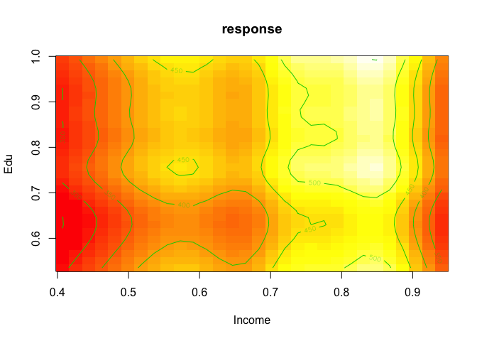

```r
vis.gam(mod_gam2, type='response', plot.type='contour')
```

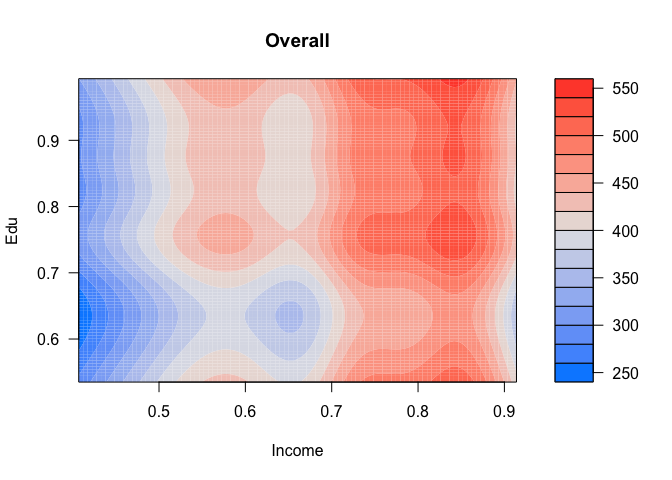

```r
visreg2d(mod_gam2, xvar='Income', yvar='Edu', scale='response')
```